# Runtime and Memory for Genome-Scale Tm Profiling: an hg38 Benchmark Guide

Junhui Li, Lihua Julie Zhu

2026-09-12

# Introduction

This vignette answers two practical questions that come up as soon as Tm profiling is scaled from a bacterial genome to the human genome (hg38):

1. For a **single chromosome** (chr1), how long does the pipeline take, how much memory does it use, and why does supplying a multi-worker `BPPARAM` to `tm_calculate()` **not** make it faster?
2. For the **whole genome**, how should the work be parallelized, what are sensible parameter settings, and what runtime and memory should be budgeted?

All timings below were measured on a 6-core (12-thread) Intel MacBook Pro with 16 GB RAM, R 4.4, macOS, with the package’s compiled (Rcpp) nearest-neighbor core. Absolute numbers will differ on other machines; the *structure* of the results — which parts scale, which parts do not — will not. None of the chunks are evaluated when the vignette is built; run them interactively to reproduce the measurements on your own hardware.

```r
library(TmCalculator)
library(BiocParallel)

pkg <- "BSgenome.Hsapiens.UCSC.hg38"
suppressPackageStartupMessages(library(pkg, character.only = TRUE))
genome <- get(pkg, envir = asNamespace(pkg))
```

# Measuring time and memory

Three tools cover almost every need. Wall-clock time comes from `system.time()` (read the `elapsed` column; for parallel runs `user` and `system` only reflect the manager process). The peak of R-managed memory over a code block comes from the `gc(reset = TRUE)` idiom. The true resident size of the current process — including C++ allocations that R’s GC does not see — comes from `ps::ps_memory_info()`.

```r
gc(reset = TRUE)                      # reset the "max used" high-water mark
## ... run the code to be measured ...
gc()                                  # read peak from the "max used" column

ps::ps_memory_info()[["rss"]] / 1e9   # current process resident set, GB
```

(Earlier releases exported a `gc()` of their own, for the GC *content* of a sequence, which masked R’s garbage collector once the package was attached. That function is now `gc_content()`, so no `base::` prefix is needed.)

For `SnowParam()` workers the manager cannot see worker memory at all; record it inside the worker function and return it with the result (this pattern is used in the whole-genome section below).

# A ten-second warm-up: chr21

Before committing to chr1, verify your setup on chr21 — at 46.7 Mb it is the smallest hg38 autosome and the whole pipeline finishes in about ten seconds. It is also a deliberately instructive choice: chr21 *begins* with a ~5 Mb assembly gap of `N` bases, so it exercises the N-trimming machinery that most chromosomes only touch lightly.

```r
chr_len21 <- GenomeInfoDb::seqlengths(genome)[["chr21"]]

t21 <- system.time({
  bins21 <- make_genomiccoord(bsgenome = pkg, chromosomes = "chr21",
                              window = 200L, slide = 200L,
                              start = 1, end = chr_len21, strand = "+")
  gr21   <- to_genomic_ranges_fast(list(pkg_name = pkg, seq = bins21),
                                   method = "preload_chr")
  tm21   <- tm_calculate(gr21, method = "tm_nn",
                         nn_table = "DNA_NN_SantaLucia_2004", Na = 50)
})
t21["elapsed"]        # ~10-15 s cold, ~6 s warm, on the test machine
head(tm21$gr)
```

Watch the `make_genomiccoord()` messages: N-trimming reports an effective range starting at position 5,010,001 — the leading 5 Mb of `N`s is detected in a single in-memory scan and excluded before any windows are built, leaving 208,449 windows instead of 233,549. The first run in a session pays one-time costs (reading the genome from disk, loading the thermodynamic tables); subsequent runs are roughly twice as fast. If this warm-up runs cleanly, your BSgenome installation, compiled core and memory headroom are all in working order, and the chr1 numbers below should reproduce within noise.

One benchmarking caveat that bites easily: `devtools::load_all()` compiles the C++ core at `-O0` (a debug build, ~6x slower) and leaves a mixed session state even after reinstalling. Always benchmark in a fresh session with a plain `library(TmCalculator)`; confirm with `"devtools_shims" %in% search()` returning `FALSE`.

# Part 1: a single chromosome (chr1)

## The pipeline and its serial cost

chr1 is 248,956,422 bp. Non-overlapping 200 bp windows after N-trimming give 1,244,682 windows.

```r
chr_len <- GenomeInfoDb::seqlengths(genome)[["chr1"]]

t_coord <- system.time({
  bins <- make_genomiccoord(bsgenome = pkg, chromosomes = "chr1",
                            window = 200L, slide = 200L,
                            start = 1, end = chr_len, strand = "+")
})

t_extract <- system.time({
  gr_batch <- to_genomic_ranges_fast(list(pkg_name = pkg, seq = bins),
                                     method = "preload_chr")
})

base::gc(reset = TRUE)
t_tm <- system.time({
  tm_chr1 <- tm_calculate(gr_batch, method = "tm_nn",
                          nn_table = "DNA_NN_SantaLucia_2004", Na = 50)
})
base::gc()   # "max used" = peak R memory during the Tm step

rbind(t_coord, t_extract, t_tm)[, "elapsed"]
## t_coord t_extract      t_tm
##     5.5      15.4      30.8     (freshly booted, otherwise idle machine)
```

Measured on the test machine (`R --vanilla`, freshly booted, no other applications):

| step | function | elapsed | notes |
| --- | --- | --- | --- |
| window coordinates | `make_genomiccoord()` | ~5.5 s | N-end scan loads the 249 Mb chromosome once |
| sequence extraction | `to_genomic_ranges_fast(method = "preload_chr")` | ~15 s | `extractAt()` itself is ~4 s; the rest is complement generation, the GC column and `GRanges` assembly |
| Tm calculation | `tm_calculate(method = "tm_nn")` | ~31 s | compiled core, 1.24M windows |
| **total** |  | **~52 s** |  |

On a machine with normal background load the same steps run 20-35% slower (we measured 7.3 / 19.3 / 41.5 s in an ordinary desktop session); comparisons within one section below were always measured in a single session.

Memory: `base::gc()` reported a peak of ~1.9 GB of R-managed heap during the Tm step, and a dedicated worker process running the whole chr1 pipeline reaches **~3.5-4 GB resident** (sequences, complements, a character copy handed to the compiled core, `GRanges` metadata, plus loaded packages). A useful planning figure: **budget ~4 GB per chr1-sized pipeline**, tapering to well under 2 GB for small chromosomes.

Two extraction details matter at this scale. Pass the input as `list(pkg_name = ..., seq = ...)` so the genome package is loaded once, and use `method = "preload_chr"` for dense tiling of few chromosomes (`getSeq()`-based `"vectorized"` is better for windows scattered across many chromosomes).

## Why `BPPARAM` does not accelerate a single chromosome

`tm_calculate()` accepts a `BPPARAM` and it does exactly what it advertises — yet on chr1 it does not help:

```r
system.time({
  tm_serial <- tm_calculate(gr_batch, method = "tm_nn", Na = 50)
})
## elapsed ~ 30 s

system.time({
  tm_snow <- tm_calculate(gr_batch, method = "tm_nn", Na = 50,
                          BPPARAM = SnowParam(workers = 5))
})
## elapsed ~ 55 s on the idle machine (33-80 s across repeated sessions)
## -- NEVER faster than serial
```

The serial time is stable across sessions; the parallel time is not, because its added costs (spawning workers, serializing half a gigabyte of sequence, loading packages in each worker) are highly sensitive to machine state. The decomposition explains why even its best case cannot win. Of the ~30 s serial runtime, only the per-window Tm loop (~9 s with the compiled core) is divided among workers. The rest is inherently serial or is *new* cost created by parallelization:

| component | ~time | scales with workers? |
| --- | --- | --- |
| serial preprocessing (N filtering, coercion, result assembly) | ~21 s | no — runs once in the manager |
| shipping ~0.5 GB of sequence to workers and results back | ~5 s | no — serialization is serial |
| worker startup + package loading | ~3+ s | fixed cost, *added* by parallelism |
| compiled Tm loop | ~9 s / n workers | **yes** |

This is Amdahl’s law with an unusually small parallel fraction (~30%): even with infinitely many workers the floor is ~29 s — essentially the serial runtime — and on a loaded machine the added costs balloon well past it. With the pure-R core of previous releases the loop dominated (minutes for an input of this size) and the same `SnowParam(5)` call gave a 2.8x speedup; compiling the loop moved the bottleneck into the serial part and made within-call parallelism unprofitable. **With the compiled core, the serial default (`SerialParam()`) is the fastest way to run inputs up to roughly a million windows.**

A stronger warning applies to `MulticoreParam()` on large inputs. Forked workers share the manager’s memory copy-on-write, but R’s garbage collector *writes* to every object header it marks, so each worker’s GC forces the kernel to physically duplicate inherited pages. On a chr1-scale input (measured with the pure-R core, where the effect is easiest to see), `MulticoreParam(5)` ran *slower than serial* while burning ~18 CPU-minutes of `system` time on page duplication. If you parallelize at all, prefer `SnowParam()`.

# Part 2: the whole genome

## Parallelize at the chromosome level

The serial preprocessing that defeats within-call parallelism is itself embarrassingly parallel *across chromosomes*: window building, extraction, filtering and assembly for chr2 are independent of chr1. So for genome-scale work, give each worker one whole chromosome and run the entire pipeline — coordinates, extraction, `tm_calculate()` with the serial default — inside the worker:

```r
chrs <- paste0("chr", c(1:22, "X", "Y"))
## Better: sort largest-first for load balance -- see "Choosing the
## worker count" below for the one-liner.
n_workers <- 5   # see "Choosing the worker count" below

runtime <- system.time({
  res_list <- bplapply(chrs, function(chr, pkg) {
    ## SnowParam workers are fresh R processes: load packages HERE,
    ## not in the manager session.
    suppressPackageStartupMessages(library(TmCalculator))
    suppressPackageStartupMessages(library(pkg, character.only = TRUE))

    genome  <- get(pkg, envir = asNamespace(pkg))
    chr_len <- GenomeInfoDb::seqlengths(genome)[[chr]]

    bins <- make_genomiccoord(bsgenome = pkg, chromosomes = chr,
                              window = 200L, slide = 200L,
                              start = 1, end = chr_len, strand = "+",
                              verbose = FALSE)
    gr  <- to_genomic_ranges_fast(list(pkg_name = pkg, seq = bins),
                                  method = "preload_chr")
    out <- tm_calculate(gr, method = "tm_nn",
                        nn_table = "DNA_NN_SantaLucia_2004",
                        Na = 50)$gr        # serial inside the worker

    ## Drop sequence columns before returning: Tm/GC are what we keep,
    ## and this cuts per-chromosome serialization from ~500 MB to a few MB.
    out$sequence   <- NULL
    out$complement <- NULL

    ## Record this worker's peak resident memory (GB) for budgeting.
    attr(out, "worker_rss_gb") <- ps::ps_memory_info()[["rss"]] / 1e9
    out
  }, pkg = pkg, BPPARAM = SnowParam(workers = n_workers))

  tm_genome <- unlist(GenomicRanges::GRangesList(res_list))
})

runtime
sapply(res_list, attr, "worker_rss_gb")   # per-worker memory check
length(tm_genome)                         # 14,687,330 windows
summary(tm_genome$Tm)
## Min. 47.2  1st Qu. 68.9  Median 71.5  Mean 72.0  3rd Qu. 74.8  Max. 101.1
```

Unlike within-call `BPPARAM`, this scheme parallelizes *everything*: window building, extraction, filtering and assembly, not just the Tm loop. Per-task communication is a chromosome name in and a slim `GRanges` out, so Amdahl’s law has little serial residue to bite on.

The chromosome is not the only unit of work available, though, and the choice of unit turns out to matter more than the worker count. The next section defines three schemes and the one after it measures all three over the same worker range.

## Three ways to divide the work

The three differ in *how many* tasks there are and in *when* a task is assigned to a worker.

**Static dispatch** is `SnowParam(workers = n)` left alone. BiocParallel pre-splits the task list into one contiguous chunk per worker before anything runs, so a worker that draws a light chunk finishes early and then sits idle for the rest of the run.

**Dynamic dispatch** is the same task list with `tasks = length(X)`. The manager hands out one element at a time, so a worker that finishes immediately takes the next. Sorting the chromosomes largest first makes this effective: the long tasks are placed while there is still short work left to fill the ragged end of the run.

**Segment dispatch** keeps dynamic assignment and changes the unit. Instead of 24 whole chromosomes the genome is cut into 50 Mb intervals, giving 73 tasks, and the longest single task falls from 55 s to 12 s. No schedule can finish sooner than its longest task, so this lowers the floor that the other two schemes are pressed against.

```r
sl   <- GenomeInfoDb::seqlengths(genome)[paste0("chr", c(1:22, "X", "Y"))]
chrs <- names(sort(sl, decreasing = TRUE))          # largest first

tasks_chrom <- lapply(chrs, function(ch)
  list(chr = ch, start = 1L, end = as.integer(sl[[ch]])))

## Segment boundaries must be multiples of `slide`, or the window grid
## shifts between segments and the result stops matching a whole-
## chromosome run. 50 Mb = 250,000 x 200 bp.
seg_size  <- 50e6
tasks_seg <- unlist(lapply(names(sl), function(ch) {
  st <- seq(1, sl[[ch]], by = seg_size)
  lapply(st, function(s)
    list(chr = ch, start = as.integer(s),
         end = as.integer(min(s + seg_size - 1, sl[[ch]]))))
}), recursive = FALSE)

length(tasks_chrom)   # 24
length(tasks_seg)     # 73

n <- 5
BPPARAM_static  <- SnowParam(workers = n)
BPPARAM_dynamic <- SnowParam(workers = n, tasks = length(tasks_chrom))
BPPARAM_segment <- SnowParam(workers = n, tasks = length(tasks_seg))
```

One correctness detail: a segment task must pass `trim_N = "none"` to `make_genomiccoord()`, while a whole-chromosome task should trim. Trimming inside a segment would move the window grid relative to the chromosome and the two schemes would no longer compute the same windows. Interior `N` windows are dropped afterwards in both cases, so the totals agree exactly.

## The measured sweep

All 24 chromosomes, 14,687,330 windows, 200 bp non-overlapping, freshly booted, `R --vanilla`. Wall time excludes worker start-up, which is reported separately because workers pay it concurrently and it therefore contributes its longest instance rather than the sum. Speedup is the one-worker wall time of the same strategy divided by the wall time of the configuration.

```r
# The numbers below are the measured sweep. They are held in a data frame
# rather than typed into a markdown table so that the table and the figure
# that follow cannot drift apart: both are rendered from this object.
sweep <- data.frame(
  strategy = rep(c("static", "dynamic", "segment"), each = 6),
  workers  = rep(1:6, 3),
  tasks    = rep(c(24L, 24L, 73L), each = 6),
  wall_s   = c(590.5, 431.9, 328.0, 270.0, 251.0, 244.6,
               589.1, 318.2, 237.4, 209.8, 236.4, 262.0,
               578.5, 320.2, 227.9, 193.9, 180.0, 194.0),
  startup_s = c(0.0, 7.1, 7.9, 8.1, 9.0, 9.7,
                0.0, 7.4, 7.2, 8.2, 8.7, 9.9,
                0.0, 6.9, 7.8, 8.3, 9.0, 9.8),
  work_s   = c(590.5, 613.9, 638.2, 656.5, 730.0, 906.3,
               589.1, 620.7, 683.9, 795.8, 1093.9, 1481.9,
               578.5, 629.1, 665.3, 736.9, 842.6, 1085.9),
  longest_task_s = c(55.2, 57.1, 60.8, 61.9, 70.7, 92.4,
                     53.4, 59.4, 63.6, 69.7, 88.2, 127.5,
                     11.5, 13.8, 15.6, 15.7, 17.5, 22.6),
  rss_gb   = c(4.75, 4.06, 4.06, 3.85, 3.70, 3.35,
               4.74, 3.86, 3.38, 2.90, 2.67, 2.15,
               4.87, 2.58, 2.58, 2.34, 1.86, 1.77),
  stringsAsFactors = FALSE)

# Derived rather than transcribed. Speedup is the one-worker wall clock of
# the SAME strategy over the configuration's wall clock: segmenting changes
# how much total work there is, so a ratio formed against a configuration's
# own summed task times would credit a strategy for doing more work and the
# three could not be compared. Efficiency follows from that speedup, not
# from the task times.
serial <- with(sweep, tapply(wall_s[workers == 1], strategy[workers == 1], I))
sweep$speedup    <- serial[sweep$strategy] / sweep$wall_s
sweep$efficiency <- sweep$speedup / sweep$workers
serial_work <- with(sweep, tapply(work_s[workers == 1], strategy[workers == 1], I))
sweep$work_ratio <- sweep$work_s / serial_work[sweep$strategy]
sweep$strategy <- factor(sweep$strategy, levels = c("static", "dynamic", "segment"))
sweep <- sweep[order(sweep$strategy, sweep$workers), ]
```

All 24 chromosomes, 14,687,330 windows, 200 bp non-overlapping, freshly booted, `R --vanilla`.

```r
tab <- data.frame(
  Strategy   = ifelse(duplicated(sweep$strategy), "", as.character(sweep$strategy)),
  Workers    = sweep$workers,
  Tasks      = sweep$tasks,
  `Wall (s)` = round(sweep$wall_s, 1),
  `Start-up (s)` = round(sweep$startup_s, 1),
  `Total task time (s)` = round(sweep$work_s, 1),
  `Work ratio` = round(sweep$work_ratio, 2),
  `Longest task (s)` = round(sweep$longest_task_s, 1),
  Speedup    = round(sweep$speedup, 2),
  Efficiency = round(sweep$efficiency, 2),
  `Peak RSS per worker (GB)` = round(sweep$rss_gb, 2),
  check.names = FALSE, stringsAsFactors = FALSE)
knitr::kable(tab, row.names = FALSE,
             caption = "Task-partitioning strategy and worker count.")
```

Task-partitioning strategy and worker count.

| Strategy | Workers | Tasks | Wall (s) | Start-up (s) | Total task time (s) | Work ratio | Longest task (s) | Speedup | Efficiency | Peak RSS per worker (GB) |
| --- | --- | --- | --- | --- | --- | --- | --- | --- | --- | --- |
| static | 1 | 24 | 590.5 | 0.0 | 590.5 | 1.00 | 55.2 | 1.00 | 1.00 | 4.75 |
|  | 2 | 24 | 431.9 | 7.1 | 613.9 | 1.04 | 57.1 | 1.37 | 0.68 | 4.06 |
|  | 3 | 24 | 328.0 | 7.9 | 638.2 | 1.08 | 60.8 | 1.80 | 0.60 | 4.06 |
|  | 4 | 24 | 270.0 | 8.1 | 656.5 | 1.11 | 61.9 | 2.19 | 0.55 | 3.85 |
|  | 5 | 24 | 251.0 | 9.0 | 730.0 | 1.24 | 70.7 | 2.35 | 0.47 | 3.70 |
|  | 6 | 24 | 244.6 | 9.7 | 906.3 | 1.53 | 92.4 | 2.41 | 0.40 | 3.35 |
| dynamic | 1 | 24 | 589.1 | 0.0 | 589.1 | 1.00 | 53.4 | 1.00 | 1.00 | 4.74 |
|  | 2 | 24 | 318.2 | 7.4 | 620.7 | 1.05 | 59.4 | 1.85 | 0.93 | 3.86 |
|  | 3 | 24 | 237.4 | 7.2 | 683.9 | 1.16 | 63.6 | 2.48 | 0.83 | 3.38 |
|  | 4 | 24 | 209.8 | 8.2 | 795.8 | 1.35 | 69.7 | 2.81 | 0.70 | 2.90 |
|  | 5 | 24 | 236.4 | 8.7 | 1093.9 | 1.86 | 88.2 | 2.49 | 0.50 | 2.67 |
|  | 6 | 24 | 262.0 | 9.9 | 1481.9 | 2.52 | 127.5 | 2.25 | 0.37 | 2.15 |
| segment | 1 | 73 | 578.5 | 0.0 | 578.5 | 1.00 | 11.5 | 1.00 | 1.00 | 4.87 |
|  | 2 | 73 | 320.2 | 6.9 | 629.1 | 1.09 | 13.8 | 1.81 | 0.90 | 2.58 |
|  | 3 | 73 | 227.9 | 7.8 | 665.3 | 1.15 | 15.6 | 2.54 | 0.85 | 2.58 |
|  | 4 | 73 | 193.9 | 8.3 | 736.9 | 1.27 | 15.7 | 2.98 | 0.75 | 2.34 |
|  | 5 | 73 | 180.0 | 9.0 | 842.6 | 1.46 | 17.5 | 3.21 | 0.64 | 1.86 |
|  | 6 | 73 | 194.0 | 9.8 | 1085.9 | 1.88 | 22.6 | 2.98 | 0.50 | 1.77 |

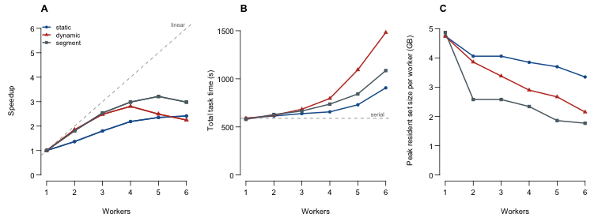

Parallel performance under three task-partitioning strategies. (A) Speedup against worker count, relative to the one-worker run of the same strategy; the dashed line marks linear speedup. (B) Total task time, summed over all tasks and measured inside the workers; values above the dashed serial reference indicate that a configuration performed more work than the serial run rather than dividing the same work among more processes. (C) Peak resident set size of the heaviest worker.

```r
# Three panels, one argument. Panel A shows that every strategy turns over
# before the cores run out, which invites the usual explanation of a ragged
# schedule. Panel B rules that out: the total task time grows with the worker
# count, so the later configurations are doing more work, not dividing a
# fixed amount badly. Panel C gives the reason and the remedy together, since
# the strategy that holds its memory down is the one whose work grows least.
pal  <- c(static = "#1B5E9C", dynamic = "#C0392B", segment = "#5C6B73")
pchs <- c(static = 16,        dynamic = 17,        segment = 15)
lv   <- levels(sweep$strategy)

op <- par(mfrow = c(1, 3), mar = c(4.4, 4.5, 2.2, 0.8), las = 1,
          cex = 0.8, mgp = c(2.8, 0.7, 0))

series <- function(col, ylab, ref = NULL, ref_lab = NULL, ymax = NULL) {
  plot(NA, xlim = range(sweep$workers),
       ylim = c(0, if (is.null(ymax)) max(sweep[[col]]) * 1.05 else ymax),
       bty = "n", xaxt = "n", xlab = "Workers", ylab = ylab)
  axis(1, at = sort(unique(sweep$workers)))
  if (!is.null(ref)) {
    abline(h = ref, lty = 2, col = "grey55")
    text(max(sweep$workers), ref, ref_lab, adj = c(1.1, -0.5),
         cex = 0.75, col = "grey40")
  }
  for (s in lv) {
    d <- sweep[sweep$strategy == s, ]
    lines(d$workers, d[[col]], col = pal[s], lwd = 2)
    points(d$workers, d[[col]], col = pal[s], pch = pchs[s])
  }
}

series("speedup", "Speedup", ymax = max(sweep$workers) * 1.02)
abline(a = 0, b = 1, lty = 2, col = "grey55")
text(max(sweep$workers), max(sweep$workers), "linear",
     adj = c(1.1, -0.4), cex = 0.75, col = "grey40")
for (s in lv) {                      # redraw over the reference line
  d <- sweep[sweep$strategy == s, ]
  lines(d$workers, d$speedup, col = pal[s], lwd = 2)
  points(d$workers, d$speedup, col = pal[s], pch = pchs[s])
}
mtext("A", side = 3, adj = 0, font = 2, line = 0.7, cex = 1.05)
legend("topleft", bty = "n", legend = lv, col = pal[lv], pch = pchs[lv],
       lwd = 2, seg.len = 1.3, cex = 0.85)

series("work_s", "Total task time (s)",
       ref = median(sweep$work_s[sweep$workers == 1]), ref_lab = "serial")
mtext("B", side = 3, adj = 0, font = 2, line = 0.7, cex = 1.05)

series("rss_gb", "Peak resident set size per worker (GB)")
mtext("C", side = 3, adj = 0, font = 2, line = 0.7, cex = 1.05)
```

```r
par(op)
```

Three readings.

**Segmenting is worth more than dispatch order.** Segment dispatch is faster than dynamic at every worker count from three upwards, and its best time, 180 s, is 30 s better than dynamic’s best and 65 s better than static’s. The mechanism is in the “longest task” column: 55 s of chr1 cannot be divided by any scheduler, and at five workers that single task is nearly a third of the whole run.

**Segmenting halves the memory.** A worker holding a 50 Mb segment needs about 1.9 GB against 3.7 GB for one holding chr1, and peak memory is what decides how many workers a machine can run at all. On this 16 GB laptop segment dispatch is both the fastest scheme and the one that leaves the most headroom, which is an unusually convenient combination.

## Why the speedup saturates

The obvious explanation for a curve that flattens is a ragged schedule: one long task holding up the end while other workers idle. The “total task time” column rules that out. It is the sum of the per-task times, measured inside the workers and excluding their package loading, so it is the amount of work the run actually performed. If the schedule were merely uneven, that column would stay flat and only the wall clock would suffer.

It does not stay flat. From one worker to six it grows by 53% under static dispatch, 88% under segment dispatch and 152% under dynamic dispatch. The later configurations are not dividing a fixed amount of work badly, they are doing more of it: the same chr1 task that takes 53 s alone takes 127 s with five siblings competing for memory bandwidth and last-level cache. Each worker is individually slower, and past a certain point adding one slows the others by more than it contributes.

The `work ratio` column is the one to watch when you do. As long as it stays near 1.0, adding workers is buying real parallelism; once it passes about 1.3 the run is mostly paying for its own contention.

## Where the extra work lands

The summary table reports only the longest task, which hides which task that was and whether the inflation is spread evenly. The benchmark also writes a per-task file, `*_tasks.csv`, with one row per task and repetition: chromosome, interval, window count, time, and the worker’s resident memory. Recovering the per-chromosome picture from it is a few lines:

```r
tk <- utils::read.csv("bench_parallel_strategy_tasks.csv")
tk <- tk[tk$strategy == "dynamic", ]        # one task per chromosome

## Median over repetitions, one column per worker count.
w <- stats::reshape(
  stats::aggregate(secs ~ chr + n_workers, data = tk, FUN = stats::median),
  idvar = "chr", timevar = "n_workers", direction = "wide")
names(w) <- sub("^secs\\.", "w", names(w))

w$inflation <- w$w6 / w$w1                  # 6 workers vs serial
w <- w[order(-w$w1), ]
w
```

Read it two ways. Down the `w1` column is the serial cost of each chromosome, which is what sets the floor no scheduler can go below: the largest single value is the hard limit on any chromosome-level schedule, and it is the number segmenting exists to reduce. Across a row is how much slower that same task became as workers were added, with `inflation` summarising it. A ratio near 1.0 means the task was indifferent to its neighbours; a large ratio means it was competing with them for memory bandwidth and cache.

The distinction matters for choosing a strategy. If inflation were uniform across chromosomes it would be a fixed tax and segmenting would not help with it. If instead the large chromosomes inflate most, then the same property that makes them stragglers also makes them the main source of contention, and cutting them into segments addresses both at once.

## Segmenting one chromosome

Segment dispatch also answers the question Part 1 left open: how *do* you parallelize a single chromosome? Ship coordinates, not sequences. Each worker receives a `(start, end)` pair, a few dozen bytes, and runs the entire pipeline on its own segment. Every row of the Part 1 cost table becomes parallel except worker startup, because the preprocessing happens inside the workers and the half-gigabyte serialization never occurs.

```r
chr_len <- GenomeInfoDb::seqlengths(genome)[["chr1"]]

## Segment length must be a multiple of `slide` so the window grid stays
## aligned across segment boundaries (50 Mb = 250,000 x 200).
seg_starts <- seq(1, chr_len, by = 50e6)
seg <- data.frame(start = seg_starts,
                  end   = pmin(seg_starts + 50e6 - 1, chr_len))

t_seg <- system.time({
  res_seg <- bplapply(seq_len(nrow(seg)), function(i, seg, pkg) {
    suppressPackageStartupMessages(library(TmCalculator))
    suppressPackageStartupMessages(library(pkg, character.only = TRUE))
    bins <- make_genomiccoord(bsgenome = pkg, chromosomes = "chr1",
                              window = 200L, slide = 200L,
                              start = seg$start[i], end = seg$end[i],
                              strand = "+", trim_N = "none",
                              verbose = FALSE)
    gr <- to_genomic_ranges_fast(list(pkg_name = pkg, seq = bins),
                                 method = "preload_chr")
    out <- tm_calculate(gr, method = "tm_nn",
                        nn_table = "DNA_NN_SantaLucia_2004", Na = 50)$gr
    out$sequence <- NULL; out$complement <- NULL
    out
  }, seg = seg, pkg = pkg, BPPARAM = SnowParam(workers = 5))

  tm_chr1_seg <- sort(unlist(GenomicRanges::GRangesList(res_seg)))
})

t_seg["elapsed"]      # 38 s measured, vs ~52 s for the serial FULL pipeline
length(tm_chr1_seg)   # 1,152,300
```

Mind the comparison scope: 38 s covers the *entire* pipeline (windows, extraction, Tm), so the serial reference is the ~52 s pipeline total from Part 1 — a **1.35x** speedup — not the 30 s Tm-only figure. Modest, but it is the only single-chromosome parallelization that wins at all (within-call `SnowParam` *lost* to serial above), and the result is verifiably identical: 1,152,300 windows equals the serial run’s 1,244,682 generated minus its 92,382 N-gap windows, exactly. That equivalence is by construction — `trim_N = "none"` keeps the window grid identical across segments (the “Skipped … regions” warning from `tm_calculate()` is expected; hg38 chr1 carries an ~18 Mb interior centromeric gap), and the 50 Mb segment length is a multiple of `slide`.

The gain is capped well below worker-count because each worker pays fixed costs the serial run pays once: loading packages and reading the same 249 Mb chromosome to extract its segment, with five workers contending for the same file. Per-worker memory stays moderate, about 1 to 2 GB, since only a 50 Mb segment is windowed at a time.

## Choosing the strategy and the worker count

Take segment dispatch. It was fastest at every worker count from three upwards, it halves the per-worker memory, and the memory saving is what lets a machine run more workers in the first place. Chromosome-level dispatch is worth keeping only if the downstream analysis wants whole chromosomes back as single objects.

For the worker count, two constraints, take the minimum:

```r
mem_gb    <- 16                                     # your machine
cores     <- parallel::detectCores(logical = FALSE) # physical cores
per_worker_gb <- 2                                  # 50 Mb segment task
n_workers <- min(cores - 1L, floor((mem_gb - 4) / per_worker_gb))
n_workers
## 16 GB / 6 cores  -> 5 workers, which is what the sweep found fastest
## 32 GB / 8 cores  -> 7 workers
## 64 GB / 10 cores -> 9 workers
```

Use 2 GB per worker for segment tasks and 4 GB for whole-chromosome tasks; those are the measured peaks, not estimates. Do not count hyperthreads. The compiled core is CPU-bound and logical cores add little beyond scheduler overhead, and the sweep above shows the run is already contending for cache at five real cores.

Treat the memory bound as hard. When workers do collide the system swaps, and a swapping parallel run is slower than serial: we measured 19 GB of swap and a wedged machine in exactly this state, aggravated by leftover workers from interrupted runs.

Two smaller settings that the sweep shows are not optional. Sort the tasks largest-first, because the scheduler deals them out in order and a long task placed last has nothing left to overlap with. And pass `tasks = length(X)` to `SnowParam()`; leaving it at the default is what makes a run “static”, and that cost 60 s at four workers here for no benefit at all.

```r
sl   <- GenomeInfoDb::seqlengths(genome)
chrs <- names(sort(sl[paste0("chr", c(1:22, "X", "Y"))], decreasing = TRUE))
```

## Reproducing the sweep

The whole measurement is scripted, including the per-task instrumentation that separates worker start-up from compute and records each worker’s peak resident memory:

```bash
Rscript inst/scripts/bench_parallel_strategy.R \
  --workers 1,2,3,4,5,6 --reps 3 --outfile bench_parallel_strategy.csv

Rscript inst/scripts/make_table6.R  --csv bench_parallel_strategy.csv
Rscript inst/scripts/make_figure5.R --csv bench_parallel_strategy.csv
```

Include one worker in the sweep. It is the baseline every speedup is divided by, and BiocParallel runs a single worker inside the manager rather than spawning one, so that point measures the serial cost with nothing to serialise. Without it the only available ratios are against each strategy’s own summed task times, which are not comparable across strategies because segmenting changes how much total work there is.

For a cluster, `inst/scripts/bench_parallel_cluster.R` adds the three things a shared machine needs: it reads the allocated core count from the scheduler rather than from `detectCores()`, which on a shared node reports the whole machine and oversubscribes badly; it stages the genome package on node-local disk, because BSgenome reads the `.2bit` at random offsets and several workers hitting a shared filesystem measure storage latency instead of software; and it sweeps physical cores only.

## Housekeeping

Four operational notes. First, benchmark in a session that did *not* restore a saved workspace (`[Workspace loaded from ~/.RData]` at startup means gigabytes of old objects are already resident); disable “Restore .RData at startup” in RStudio or start `R --vanilla`. Second, `SnowParam()` workers load the *installed* package: after `devtools::load_all()` development changes, run `devtools::install()` before benchmarking, and note that `load_all()` compiles C++ at `-O0` — time only the installed build. The same applies to `devtools::build_vignettes()`, which evaluates vignette code against a `-O0` debug build (timings come out ~6x slow); set `options(pkg.build_extra_flags = FALSE)` to disable the debug flags, or rely on `R CMD build` / `devtools::check()`, which install with normal optimization before running vignettes. Changing the flag option does *not* trigger recompilation — stale `-O0` object files in `src/` are reused as long as sources are unchanged — so run `pkgbuild::clean_dll()` after changing it. Third, if a parallel run errors or is interrupted, workers can linger and hold gigabytes; check for orphaned `R` processes (Activity Monitor on macOS, `ps aux | grep R` elsewhere) before rerunning. Fourth, worker `message()` output is buffered until each task finishes — a silent console does not mean a hung run; watch the worker processes’ CPU instead.

# Summary

For hg38 with the compiled nearest-neighbor core, run single chromosomes serially. Leave `BPPARAM` at its default: within-call parallelism cannot beat Amdahl’s law when the parallel fraction is about 30%.

For the whole genome, parallelize outside the call, over 50 Mb segments rather than whole chromosomes, with `SnowParam(workers = n, tasks = length(X))` and the tasks sorted largest-first. On a 6-core, 16 GB laptop that runs 14.7 million windows in 180 s at five workers, against 578 s serially, a speedup of 3.21 at 1.9 GB per worker. The same run organised by chromosome takes 210 s at best and needs 2.9 GB per worker.